# Analysis of Titanite solubility experiments

John C. Ayers

### Import normalized EDS glass analyses

```r
TitaniteExpts <- read_csv("TitaniteExptsV3.csv")
skimr::skim(TitaniteExpts)
```

Data summary

| Name | TitaniteExpts |
| --- | --- |
| Number of rows | 39 |
| Number of columns | 20 |
| _______________________ |  |
| Column type frequency: |  |
| character | 6 |
| numeric | 14 |
| ________________________ |  |
| Group variables | None |

**Variable type: character**

| skim_variable | n_missing | complete_rate | min | max | empty | n_unique | whitespace |
| --- | --- | --- | --- | --- | --- | --- | --- |
| DF_Model | 0 | 1 | 1 | 1 | 0 | 2 | 0 |
| Expt | 0 | 1 | 5 | 8 | 0 | 39 | 0 |
| Type | 0 | 1 | 11 | 15 | 0 | 2 | 0 |
| SM | 0 | 1 | 3 | 9 | 0 | 7 | 0 |
| Titanite | 0 | 1 | 1 | 1 | 0 | 2 | 0 |
| Rutile | 0 | 1 | 1 | 1 | 0 | 3 | 0 |

**Variable type: numeric**

| skim_variable | n_missing | complete_rate | mean | sd | p0 | p25 | p50 | p75 | p100 | hist |
| --- | --- | --- | --- | --- | --- | --- | --- | --- | --- | --- |
| TC | 0 | 1 | 1016.03 | 145.60 | 800.00 | 900.00 | 1000.00 | 1100.00 | 1300.00 | ▇▆▃▂▂ |
| Pkb | 0 | 1 | 6.28 | 1.65 | 5.00 | 5.00 | 5.00 | 8.00 | 10.00 | ▇▁▅▁▁ |
| H2O | 0 | 1 | 3.70 | 2.16 | 0.00 | 1.95 | 3.80 | 4.00 | 9.90 | ▅▇▅▁▁ |
| TimeH | 0 | 1 | 100.97 | 51.03 | 18.00 | 68.00 | 100.00 | 120.00 | 240.00 | ▅▇▇▃▁ |
| SiO2 | 0 | 1 | 70.39 | 4.25 | 62.32 | 66.94 | 70.45 | 73.89 | 77.67 | ▃▇▅▇▅ |
| Al2O3 | 0 | 1 | 14.16 | 1.98 | 9.31 | 12.72 | 13.88 | 15.80 | 17.77 | ▁▆▇▇▆ |
| Na2O | 0 | 1 | 3.07 | 0.64 | 1.97 | 2.55 | 2.93 | 3.54 | 4.96 | ▆▇▆▂▁ |
| K2O | 0 | 1 | 4.84 | 0.90 | 3.11 | 4.26 | 4.65 | 5.29 | 6.99 | ▂▇▅▃▂ |
| CaO | 0 | 1 | 3.33 | 1.88 | 0.72 | 2.08 | 2.75 | 4.48 | 9.39 | ▇▆▃▂▁ |
| FeO | 0 | 1 | 0.39 | 0.76 | 0.01 | 0.02 | 0.03 | 0.56 | 3.31 | ▇▂▁▁▁ |
| MgO | 0 | 1 | 0.52 | 0.47 | 0.06 | 0.08 | 0.33 | 0.91 | 1.43 | ▇▁▂▂▂ |
| TiO2 | 0 | 1 | 2.98 | 2.72 | 0.32 | 1.31 | 2.36 | 3.69 | 13.52 | ▇▃▁▁▁ |
| MnO | 0 | 1 | 0.04 | 0.02 | 0.01 | 0.02 | 0.03 | 0.05 | 0.10 | ▇▆▅▁▁ |
| P2O5 | 0 | 1 | 0.14 | 0.14 | 0.00 | 0.01 | 0.05 | 0.27 | 0.41 | ▇▂▂▂▂ |

### Convert oxides to cation concentrations

```r
GlassCations <- TitaniteExpts %>%
  mutate(
    Si = SiO2 / 60.0848,
    Al = 2 * Al2O3 / 101.961,
    Na = 2 * Na2O / 61.979,
    K = 2 * K2O / 94.194,
    Ca = CaO / 56.0794,
    Fe = FeO / 71.8464,
    Mg = MgO / 40.3044,
    Ti = TiO2 / 79.8988,
    Mn = MnO / 70.9374,
    P = 2 * P2O5 / 141.945,
    eCa = (CaO/56.0794 - Al2O3/101.961 + K2O/94.194 + Na2O/61.979),
    CationSum = (Si + Al + Na + K + Ca + Fe + Mg + Ti + Mn + P)
  )
```

### Calculate cation fractions

```r
CationFractions <- select(GlassCations, Expt, Type, SM, TC, Pkb, H2O, TimeH, Titanite, Rutile, TiO2, Si:CationSum)
f <- match("Si", names(CationFractions))
l <- match("P", names(CationFractions))
for (i in f:l) {
  CationFractions[(i)] <- CationFractions[(i)] / CationFractions$CationSum
}
```

### Calculate melt composition parameters

Formula for calculating melt composition parameter M (Ryerson and Watson 1987)

$$M = \frac{(Na + K + 2*Ca)}{(Si * Al)}$$

```r
CationFractions <- CationFractions %>%
  mutate(
    M = (Na + K + 2 * Ca) / (Si * Al),
    FM = (Na + K + 2 * (Ca + Fe + Mg)) / (Si * Al),
    C = (10*eCa)/(Si*Al),
    TK = TC + 273.15,
    InvTK = 1 / TK,
    PInvTK = (Pkb * 1000 - 1) * InvTK
      )
```

### Glass Compositions

```r
# Insert table of glass compositions
GlassComps <- select(GlassCations, Expt, TC:TimeH, SiO2:P2O5)
knitr::kable(GlassComps, digits = 2)
```

| Expt | TC | Pkb | H2O | TimeH | SiO2 | Al2O3 | Na2O | K2O | CaO | FeO | MgO | TiO2 | MnO | P2O5 |
| --- | --- | --- | --- | --- | --- | --- | --- | --- | --- | --- | --- | --- | --- | --- |
| SpDis_1 | 1300 | 6 | 0.0 | 22 | 67.63 | 11.27 | 2.43 | 4.02 | 2.29 | 1.14 | 0.08 | 11.03 | 0.10 | 0.01 |
| SpDis_10 | 1100 | 8 | 5.9 | 71 | 76.00 | 12.89 | 2.33 | 4.22 | 2.07 | 0.02 | 0.07 | 2.40 | 0.02 | 0.01 |
| SpDis_11 | 1100 | 8 | 9.7 | 64 | 75.39 | 12.66 | 2.31 | 4.43 | 2.45 | 0.01 | 0.07 | 2.65 | 0.03 | 0.01 |
| SpDis_12 | 1200 | 8 | 1.0 | 29 | 73.85 | 12.05 | 3.71 | 4.42 | 1.92 | 0.99 | 0.08 | 3.74 | 0.05 | 0.01 |
| SpDis_13 | 1200 | 8 | 1.8 | 71 | 74.81 | 12.41 | 3.54 | 4.65 | 1.77 | 0.02 | 0.08 | 3.25 | 0.02 | 0.01 |
| SpDis_15 | 1200 | 8 | 5.9 | 49 | 69.92 | 11.69 | 4.96 | 3.89 | 4.18 | 0.01 | 0.07 | 5.25 | 0.02 | 0.01 |
| SpDis_16 | 1000 | 8 | 9.9 | 114 | 76.37 | 13.08 | 2.27 | 4.26 | 2.41 | 0.02 | 0.08 | 1.40 | 0.05 | 0.01 |
| SpDis_17 | 1000 | 8 | 6.0 | 117 | 68.17 | 11.87 | 4.08 | 3.55 | 0.88 | 0.01 | 0.06 | 0.81 | 0.03 | 0.02 |
| SpDis_18 | 925 | 8 | 6.2 | 118 | 77.67 | 13.59 | 2.51 | 4.69 | 0.72 | 0.02 | 0.07 | 0.55 | 0.04 | 0.00 |
| SpDis_2 | 1300 | 8 | 1.0 | 28 | 73.05 | 11.15 | 1.97 | 3.55 | 4.95 | 0.09 | 0.10 | 7.88 | 0.02 | 0.01 |
| SpDis_21 | 1000 | 8 | 2.0 | 240 | 76.33 | 12.83 | 3.33 | 4.80 | 1.14 | 0.02 | 0.07 | 1.48 | 0.01 | 0.01 |
| SpDis_3 | 1300 | 8 | 1.9 | 18 | 62.32 | 9.31 | 2.63 | 3.11 | 9.39 | 0.03 | 0.10 | 13.52 | 0.02 | 0.01 |
| SpDis_4 | 1300 | 8 | 4.3 | 18 | 74.44 | 12.56 | 2.79 | 4.42 | 2.83 | 0.02 | 0.06 | 2.83 | 0.02 | 0.01 |
| SpDis_7 | 1100 | 8 | 1.0 | 65 | 76.10 | 12.79 | 3.44 | 4.55 | 1.05 | 0.74 | 0.07 | 1.31 | 0.03 | 0.01 |
| SpG_10 | 1000 | 5 | 4.0 | 72 | 72.80 | 13.09 | 2.65 | 5.29 | 2.76 | 0.02 | 0.33 | 3.03 | 0.02 | 0.01 |
| SpG_11 | 800 | 5 | 4.0 | 168 | 74.56 | 13.65 | 2.69 | 6.98 | 1.15 | 0.04 | 0.34 | 0.54 | 0.04 | 0.01 |
| SpG_12 | 800 | 5 | 4.0 | 168 | 71.82 | 14.70 | 3.71 | 5.03 | 2.55 | 0.03 | 0.67 | 1.29 | 0.05 | 0.15 |
| SpG_15 | 800 | 5 | 3.7 | 168 | 73.44 | 15.44 | 3.10 | 4.46 | 2.15 | 0.51 | 0.25 | 0.32 | 0.02 | 0.30 |
| SpG_16 | 800 | 5 | 3.7 | 168 | 70.45 | 17.35 | 4.13 | 3.64 | 2.64 | 0.72 | 0.38 | 0.33 | 0.05 | 0.31 |
| SpG_17 | 900 | 5 | 3.9 | 120 | 68.66 | 15.80 | 2.93 | 5.55 | 3.68 | 0.05 | 1.01 | 2.04 | 0.04 | 0.24 |
| SpG_18 | 900 | 5 | 3.7 | 120 | 65.53 | 16.95 | 3.67 | 4.37 | 5.24 | 0.05 | 1.43 | 2.36 | 0.06 | 0.34 |
| SpG_19 | 1000 | 5 | 3.8 | 96 | 67.47 | 15.20 | 2.82 | 5.44 | 4.60 | 0.03 | 0.96 | 3.19 | 0.02 | 0.27 |
| SpG_20 | 1000 | 5 | 3.7 | 96 | 64.22 | 16.45 | 3.55 | 4.26 | 6.05 | 0.03 | 1.39 | 3.64 | 0.05 | 0.36 |
| SpG_23 | 900 | 5 | 1.5 | 100 | 72.47 | 14.80 | 2.47 | 5.01 | 2.72 | 0.02 | 0.69 | 1.67 | 0.03 | 0.12 |
| SpG_28 | 900 | 5 | 5.9 | 145 | 63.62 | 16.09 | 3.37 | 4.23 | 6.58 | 0.02 | 1.34 | 4.35 | 0.02 | 0.38 |
| SpG_29 | 1000 | 5 | 0.0 | 168 | 66.21 | 15.81 | 3.14 | 5.29 | 3.61 | 3.19 | 0.82 | 1.66 | 0.04 | 0.23 |
| SpG_30 | 1000 | 5 | 1.8 | 168 | 65.52 | 16.62 | 3.66 | 4.81 | 3.78 | 3.31 | 0.51 | 1.32 | 0.06 | 0.41 |
| SpG_32 | 900 | 5 | 2.4 | 120 | 69.56 | 16.00 | 2.90 | 5.95 | 2.75 | 0.69 | 0.88 | 1.02 | 0.04 | 0.21 |
| SpG_33 | 1000 | 10 | 3.5 | 96 | 68.29 | 15.62 | 2.98 | 5.53 | 4.06 | 0.04 | 1.00 | 2.21 | 0.03 | 0.24 |
| SpG_34 | 1000 | 10 | 4.0 | 96 | 65.51 | 16.78 | 3.57 | 4.44 | 5.34 | 0.06 | 1.41 | 2.49 | 0.06 | 0.34 |
| SpG_7 | 900 | 5 | 4.0 | 120 | 73.94 | 13.49 | 2.50 | 6.99 | 1.28 | 0.62 | 0.29 | 0.80 | 0.08 | 0.01 |
| SpG_8 | 900 | 5 | 3.8 | 120 | 71.32 | 14.36 | 2.73 | 6.00 | 2.34 | 1.29 | 0.62 | 1.13 | 0.09 | 0.12 |
| SpG13 | 1100 | 5 | 3.9 | 48 | 70.57 | 12.57 | 3.97 | 5.21 | 3.41 | 0.02 | 0.31 | 3.63 | 0.02 | 0.05 |
| SpG14 | 1100 | 5 | 3.9 | 48 | 69.80 | 13.88 | 2.41 | 4.62 | 4.36 | 0.01 | 0.63 | 4.12 | 0.04 | 0.14 |
| SpG21 | 1100 | 5 | 3.8 | 72 | 66.42 | 14.94 | 2.72 | 5.28 | 5.04 | 0.02 | 0.96 | 4.28 | 0.01 | 0.27 |
| SpG22 | 1100 | 5 | 3.8 | 72 | 63.36 | 16.10 | 3.45 | 4.14 | 6.53 | 0.01 | 1.36 | 4.60 | 0.01 | 0.37 |
| SpG24 | 900 | 5 | 1.8 | 100 | 73.28 | 13.42 | 2.44 | 6.65 | 1.92 | 0.32 | 0.21 | 1.73 | 0.02 | 0.01 |
| SpG27 | 900 | 5 | 5.6 | 145 | 65.77 | 15.09 | 3.12 | 5.11 | 5.03 | 0.03 | 0.94 | 4.46 | 0.01 | 0.27 |
| SpG31 | 900 | 5 | 3.5 | 120 | 68.42 | 17.77 | 2.59 | 5.99 | 2.10 | 0.80 | 0.32 | 1.93 | 0.06 | 0.02 |

### Time series plots for titanite-saturated experiments

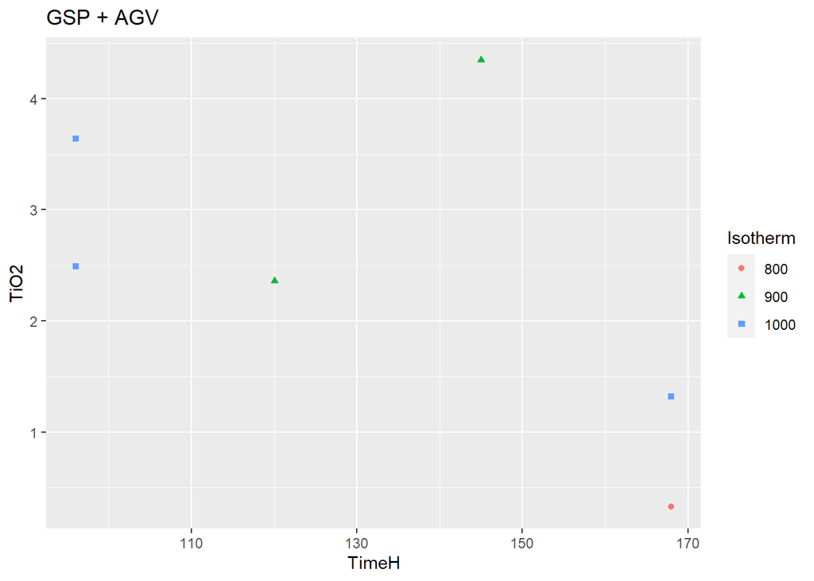

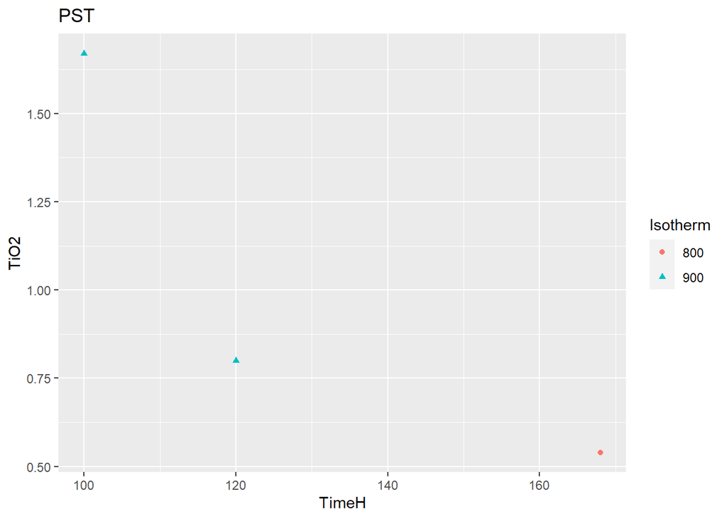

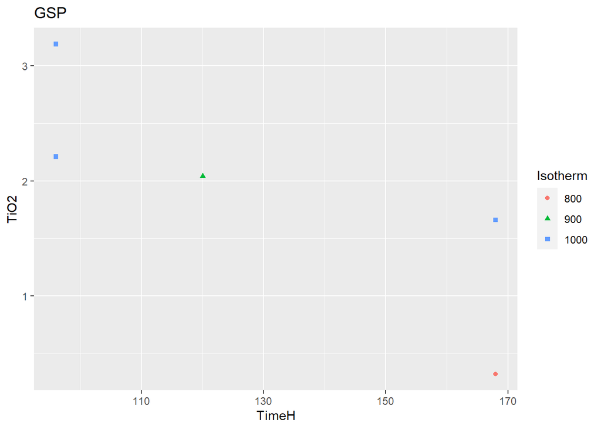

```r
NoTitanite <- filter(CationFractions, Titanite == "N")
CationFractionsTitanite <- filter(CationFractions, Titanite == "Y")
CationFractionsTitanite$Isotherm <- factor(CationFractionsTitanite$TC)
SMplot <- c("GSP + AGV", "PST", "GSP")
for (i in seq_along(SMplot)) {
  Comp <- filter(CationFractionsTitanite, SM == SMplot[i])
  p <- ggplot(Comp, aes(x = TimeH, y = TiO2, shape = Isotherm, color = Isotherm)) +
    geom_point() +
    labs(title = as.name(SMplot[i]))
  print(p)
}
```

Time series a bit concerning, since many isotherms seem to have a negative slope, suggesting that titanite crystallization is kinetically inhibited.

### Correlation matrix

```r
CorrTest <- select(CationFractionsTitanite, TiO2, TimeH, Pkb, H2O, Ca, M:PInvTK)
cor(CorrTest)
```

```
##              TiO2       TimeH         Pkb         H2O          Ca          M
## TiO2    1.0000000 -0.64383128  0.21068691 -0.29154463  0.63115871  0.7667920
## TimeH  -0.6438313  1.00000000 -0.43121628  0.05159954 -0.26520742 -0.3766911
## Pkb     0.2106869 -0.43121628  1.00000000  0.18517533 -0.00807254  0.1056891
## H2O    -0.2915446  0.05159954  0.18517533  1.00000000 -0.09508713 -0.1795079
## Ca      0.6311587 -0.26520742 -0.00807254 -0.09508713  1.00000000  0.8821955
## M       0.7667920 -0.37669111  0.10568908 -0.17950794  0.88219555  1.0000000
## FM      0.6879387 -0.26508669 -0.02939884 -0.27586642  0.91282388  0.9623302
## C       0.7891510 -0.43290901  0.17477239 -0.14713408  0.82763167  0.9899932
## TK      0.7299576 -0.80742487  0.57191815 -0.21772721  0.24642120  0.4207026
## InvTK  -0.6903073  0.79401433 -0.59636787  0.18928234 -0.23780078 -0.3981171
## PInvTK -0.1200184 -0.08951264  0.90064584  0.33167388 -0.14699348 -0.1044689
##                 FM           C         TK      InvTK      PInvTK
## TiO2    0.68793874  0.78915103  0.7299576 -0.6903073 -0.12001841
## TimeH  -0.26508669 -0.43290901 -0.8074249  0.7940143 -0.08951264
## Pkb    -0.02939884  0.17477239  0.5719182 -0.5963679  0.90064584
## H2O    -0.27586642 -0.14713408 -0.2177272  0.1892823  0.33167388
## Ca      0.91282388  0.82763167  0.2464212 -0.2378008 -0.14699348
## M       0.96233021  0.98999322  0.4207026 -0.3981171 -0.10446888
## FM      1.00000000  0.91894524  0.3147931 -0.3019686 -0.20843294
## C       0.91894524  1.00000000  0.4852093 -0.4596684 -0.05695934
## TK      0.31479311  0.48520925  1.0000000 -0.9925682  0.16167039
## InvTK  -0.30196861 -0.45966839 -0.9925682  1.0000000 -0.19490592
## PInvTK -0.20843294 -0.05695934  0.1616704 -0.1949059  1.00000000
```

### Scatterplot matrices

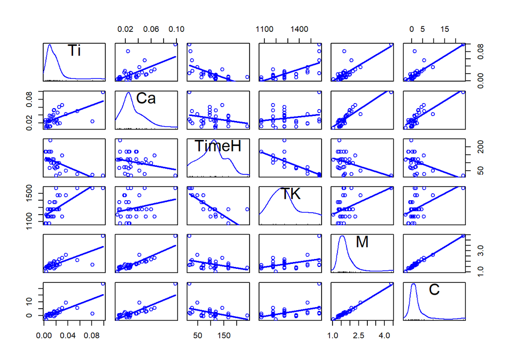

```r
CationFractionsTitanite$Type <- factor(CationFractionsTitanite$Type)
scatterplotMatrix(~ Ti + Ca + TimeH + TK + M +C, data = CationFractionsTitanite, smooth = FALSE)
```

Glass TiO2 concentration is positively correlated with melt composition parameter M and TK and negatively correlated with time and InvTK.

### Best subsets regression

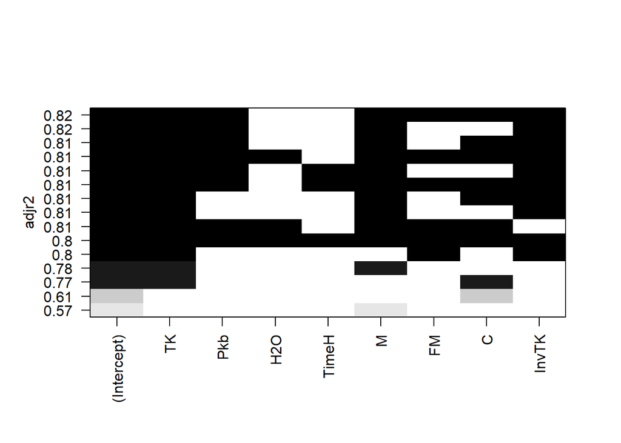

```r
leaps <- regsubsets(TiO2 ~ TK + Pkb + H2O + TimeH + M + FM + C + InvTK, data = CationFractionsTitanite, nbest = 2)
plot(leaps, scale = "adjr2")
```

```r
# summary(leaps)
```

Since TK and InvTK convey the same information, and theory suggests that titanite solubility should depend on inverse temperature, and TK has a higher correlation coefficient, we include only TK in the analysis. Results of subsets regression suggest that M, TK, Pkb, and TimeH are the significant independent variables.

### Preliminary regression fit

```r
fit <- lm(TiO2 ~ M + TK + Pkb + TimeH, data = CationFractionsTitanite)
summary(fit)
```

```
##
## Call:
## lm(formula = TiO2 ~ M + TK + Pkb + TimeH, data = CationFractionsTitanite)
##
## Residuals:
##     Min      1Q  Median      3Q     Max
## -2.6350 -0.6562  0.0390  0.5886  4.7737
##
## Coefficients:
##               Estimate Std. Error t value Pr(>|t|)
## (Intercept) -12.780205   4.133353  -3.092  0.00458 **
## M             2.646649   0.466497   5.673 5.02e-06 ***
## TK            0.010642   0.003038   3.503  0.00162 **
## Pkb          -0.344244   0.176187  -1.954  0.06115 .
## TimeH        -0.004591   0.007673  -0.598  0.55463
## ---
## Signif. codes:  0 '***' 0.001 '**' 0.01 '*' 0.05 '.' 0.1 ' ' 1
##
## Residual standard error: 1.346 on 27 degrees of freedom
## Multiple R-squared:  0.8186, Adjusted R-squared:  0.7917
## F-statistic: 30.45 on 4 and 27 DF,  p-value: 1.186e-09
```

### Refined regression model

- Pkb and TimeH are not significant, so drop
- Regression of dependent variable TiO2 (wt.%) as a function of independent variables M and TK

```r
fit <- lm(TiO2 ~ M + TK, data = CationFractionsTitanite)
summary(fit)
```

```
##
## Call:
## lm(formula = TiO2 ~ M + TK, data = CationFractionsTitanite)
##
## Residuals:
##     Min      1Q  Median      3Q     Max
## -2.3785 -0.7988 -0.1193  0.5478  5.6919
##
## Coefficients:
##               Estimate Std. Error t value Pr(>|t|)
## (Intercept) -14.321864   2.119180  -6.758 2.04e-07 ***
## M             2.830845   0.475845   5.949 1.83e-06 ***
## TK            0.009464   0.001795   5.272 1.19e-05 ***
## ---
## Signif. codes:  0 '***' 0.001 '**' 0.01 '*' 0.05 '.' 0.1 ' ' 1
##
## Residual standard error: 1.398 on 29 degrees of freedom
## Multiple R-squared:  0.7896, Adjusted R-squared:  0.7751
## F-statistic: 54.42 on 2 and 29 DF,  p-value: 1.528e-10
```

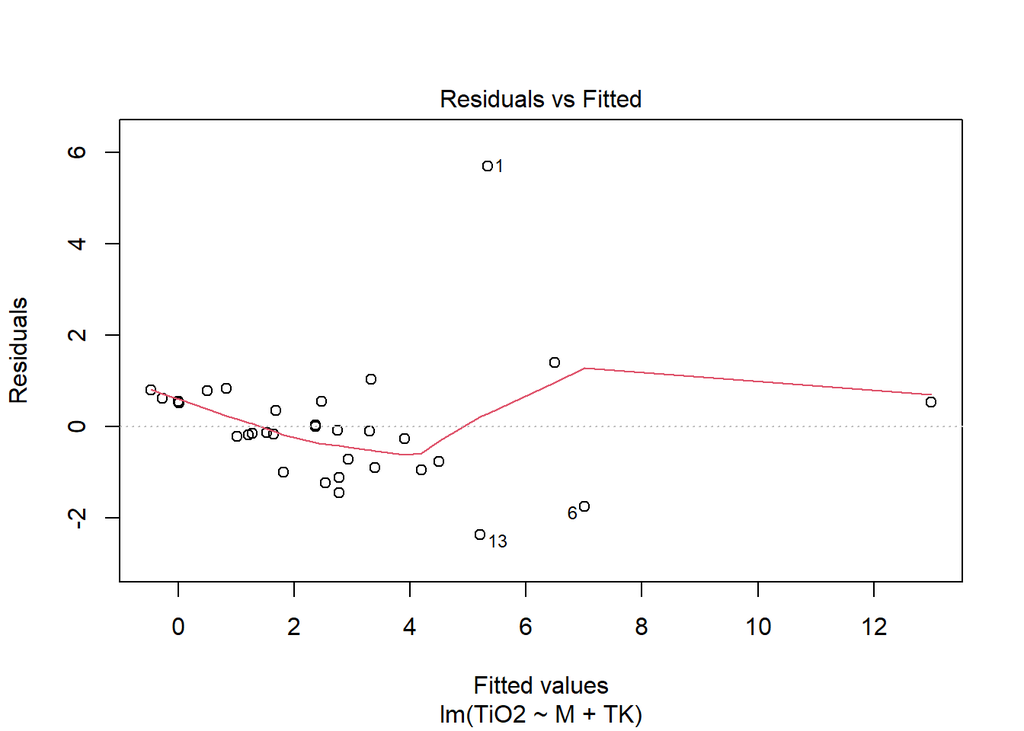

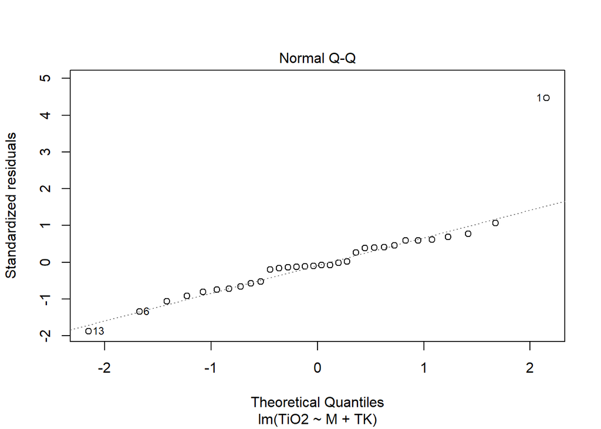

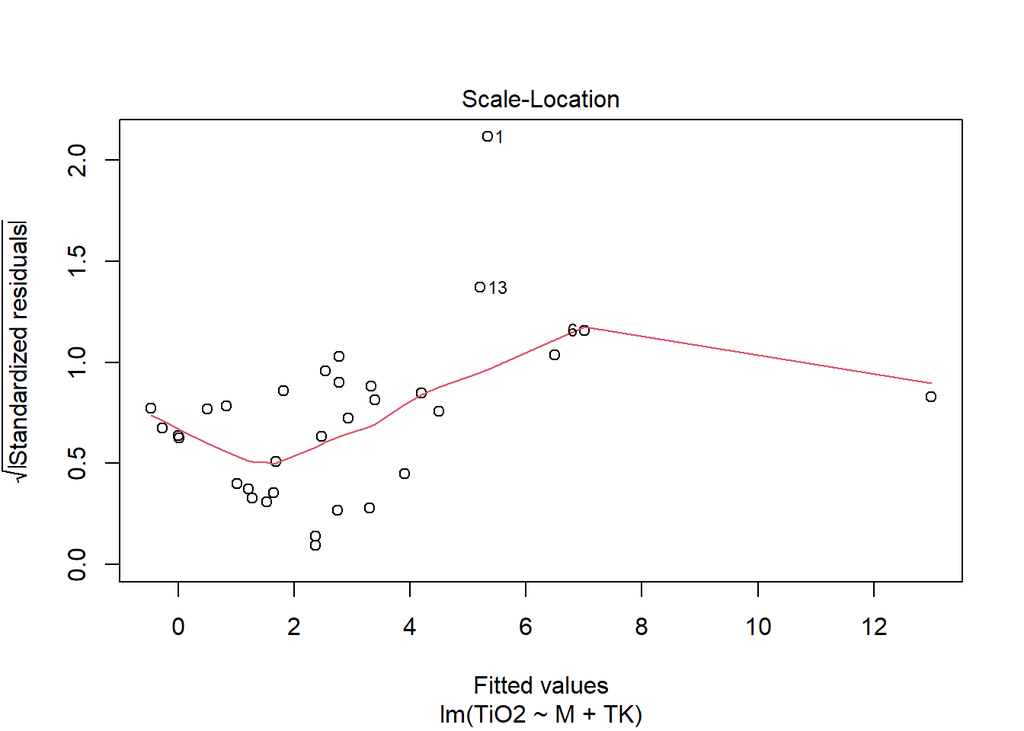

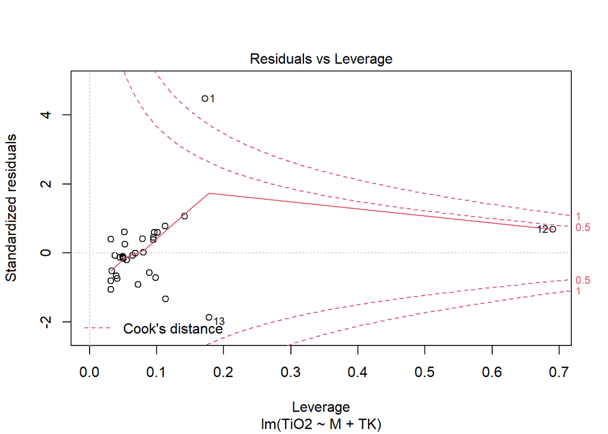

```r
plot(fit)
```

### Final regression model

```r
RegModel <- select(CationFractionsTitanite, Expt, Type, TiO2, TK, M)
DelExpts <- c("SpDis_1", "SpDis_15", "SpDis_4")
RegModel <- filter(RegModel, !(Expt %in% DelExpts))
fit <- lm(TiO2 ~ M + TK, data = RegModel)
out <- summary(fit)
out
```

```
##
## Call:
## lm(formula = TiO2 ~ M + TK, data = RegModel)
##
## Residuals:
##     Min      1Q  Median      3Q     Max
## -1.4027 -0.3712  0.0344  0.4647  1.9297
##
## Coefficients:
##               Estimate Std. Error t value Pr(>|t|)
## (Intercept) -12.481719   1.284135  -9.720 3.82e-10 ***
## M             3.213359   0.261184  12.303 2.41e-12 ***
## TK            0.007440   0.001126   6.605 5.27e-07 ***
## ---
## Signif. codes:  0 '***' 0.001 '**' 0.01 '*' 0.05 '.' 0.1 ' ' 1
##
## Residual standard error: 0.721 on 26 degrees of freedom
## Multiple R-squared:   0.93,  Adjusted R-squared:  0.9246
## F-statistic: 172.8 on 2 and 26 DF,  p-value: 9.648e-16
```

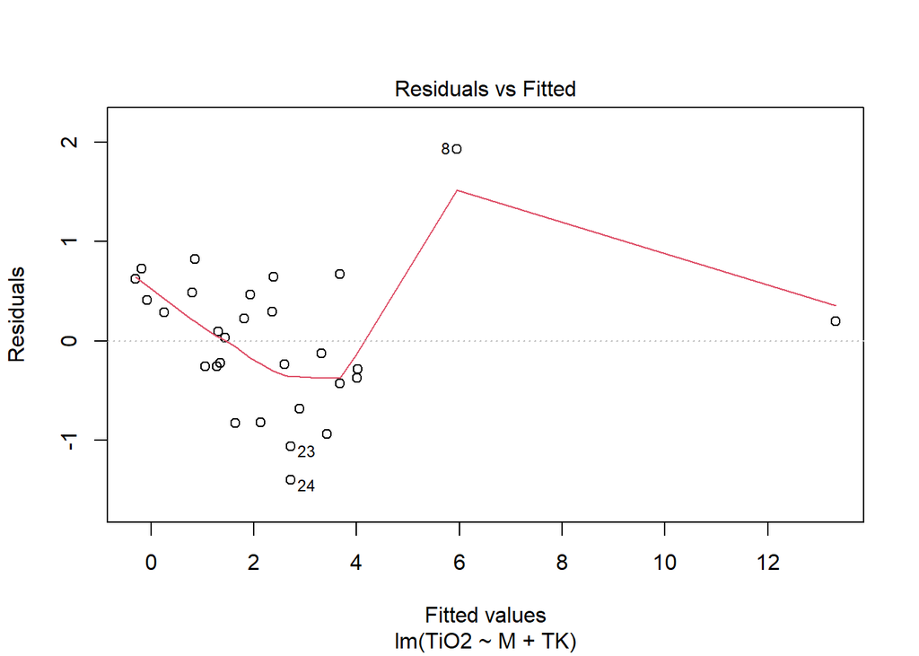

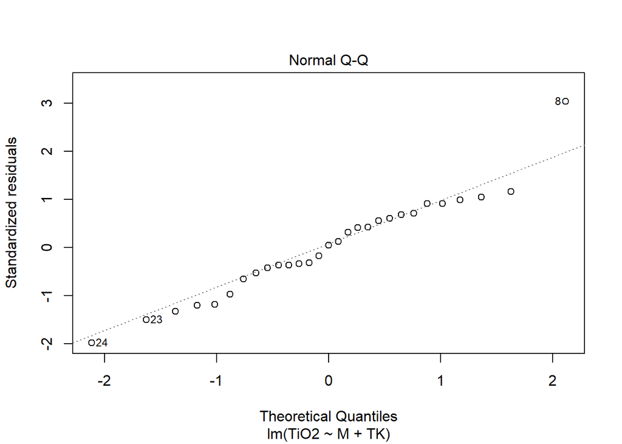

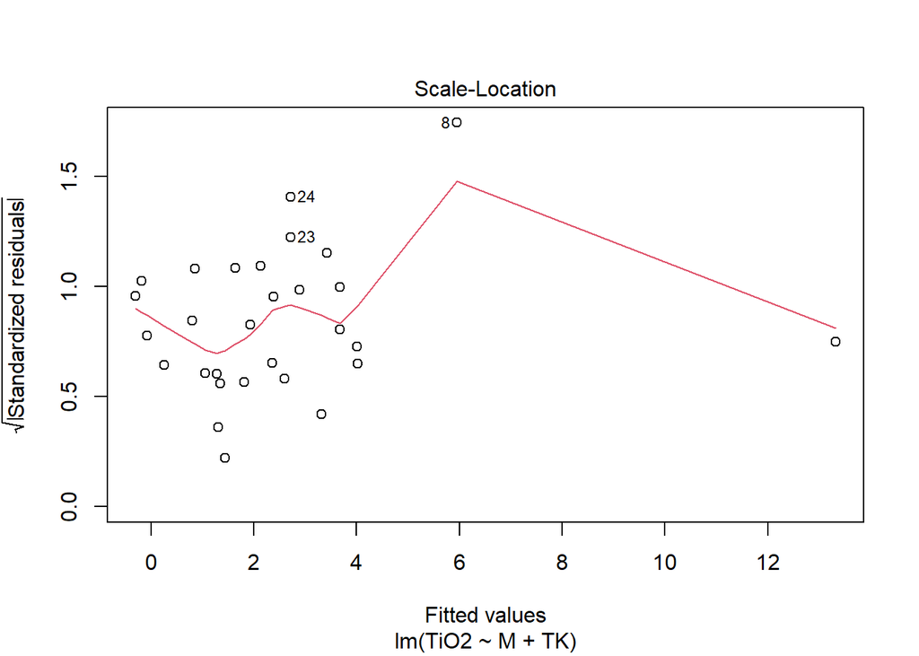

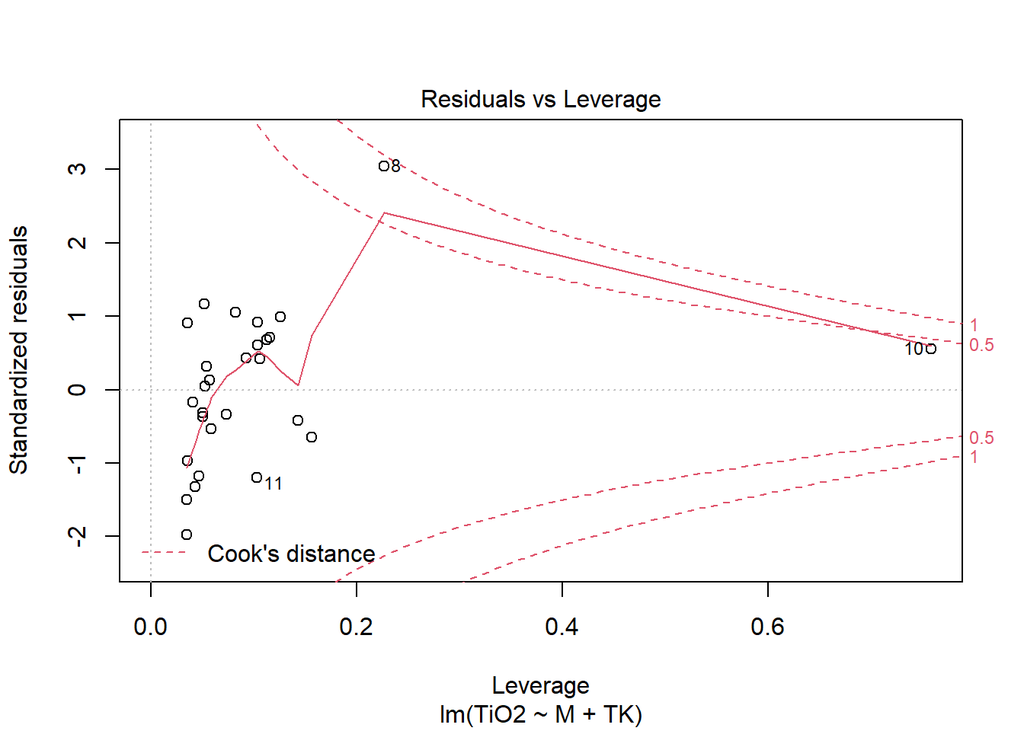

```r
plot(fit)
```

I think this is our best model. Removing more experiments doesn’t significantly improve fit.

### Test of regression assumptions

```r
library(gvlma)
gvmodel <- gvlma(fit)
summary(gvmodel)
```

```
##
## Call:
## lm(formula = TiO2 ~ M + TK, data = RegModel)
##
## Residuals:
##     Min      1Q  Median      3Q     Max
## -1.4027 -0.3712  0.0344  0.4647  1.9297
##
## Coefficients:
##               Estimate Std. Error t value Pr(>|t|)
## (Intercept) -12.481719   1.284135  -9.720 3.82e-10 ***
## M             3.213359   0.261184  12.303 2.41e-12 ***
## TK            0.007440   0.001126   6.605 5.27e-07 ***
## ---
## Signif. codes:  0 '***' 0.001 '**' 0.01 '*' 0.05 '.' 0.1 ' ' 1
##
## Residual standard error: 0.721 on 26 degrees of freedom
## Multiple R-squared:   0.93,  Adjusted R-squared:  0.9246
## F-statistic: 172.8 on 2 and 26 DF,  p-value: 9.648e-16
##
##
## ASSESSMENT OF THE LINEAR MODEL ASSUMPTIONS
## USING THE GLOBAL TEST ON 4 DEGREES-OF-FREEDOM:
## Level of Significance =  0.05
##
## Call:
##  gvlma(x = fit)
##
##                      Value p-value                Decision
## Global Stat        3.03393  0.5522 Assumptions acceptable.
## Skewness           0.46701  0.4944 Assumptions acceptable.
## Kurtosis           0.37200  0.5419 Assumptions acceptable.
## Link Function      2.16940  0.1408 Assumptions acceptable.
## Heteroscedasticity 0.02553  0.8731 Assumptions acceptable.
```

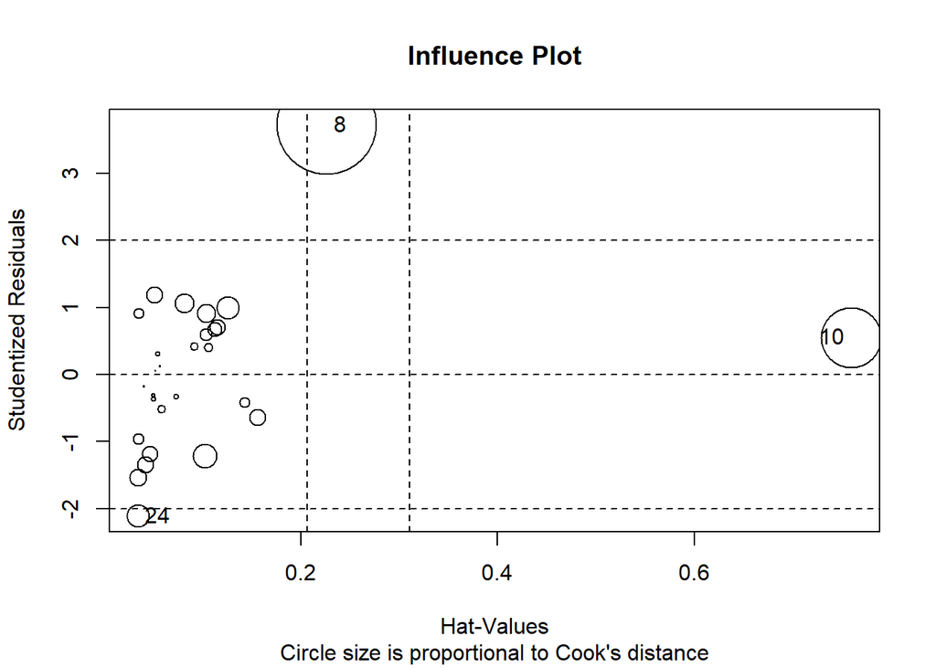

|  | StudRes | Hat | CookD |
| --- | --- | --- | --- |
| 8 | 3.719654 | 0.22668803 | 0.90510390 |
| 10 | 0.552980 | 0.75888509 | 0.32961203 |
| 24 | -2.107233 | 0.03476973 | 0.04708726 |

```r
influencePlot(fit, main = "Influence Plot", sub = "Circle size is proportional to Cook's distance")
```

```r
write.csv(RegModel, "ExptsInModelV4.csv")
```

Observations depicted as large circles may have a disproportionate influence on the parameter estimates of the model. Points with Hat values above 0.2 have high leverage.

### Model TiO2 concentrations and errors

```r
RegModel <- RegModel %>%
  mutate(
    TiO2sat = (out$coefficients[2,1] * M + out$coefficients[3,1] * TK + out$coefficients[1,1]),
    TiO2satSD = TiO2sat * sqrt((out$coefficients[2,2]/ out$coefficients[2,1])^2 + (out$coefficients[3,2] / out$coefficients[3,1])^2),
    lower = TiO2sat - TiO2satSD,
    upper = TiO2sat + TiO2satSD
  )
```

### Plot model versus measured TiO2

[figure not shown]

```r
fitparams <- c(out$coefficients[1,1], out$coefficients[2,1],  out$coefficients[3,1])
fitparams <- round(fitparams, digits = 2)
p <- ggplot(RegModel, aes(x = TiO2, y = TiO2sat, ymin = lower, ymax = upper, shape = Type, color = Type)) +
  geom_pointrange() +
  geom_abline(slope = 1, intercept = 0) +
  labs(caption = str_c("TiO2", " = ",fitparams[2], "* M ", fitparams[3], "* 1/T(K) + ",fitparams[1])) +
  theme(legend.position = "left")
# add marginal distributions
p1 <- ggMarginal(p, type = "histogram")
print(p1)
```

### log-log plot

```r
RegModel <- RegModel %>%
  mutate(
    logTiO2 = log10(TiO2),
    logTiO2sat = log10(TiO2sat)
  )
```

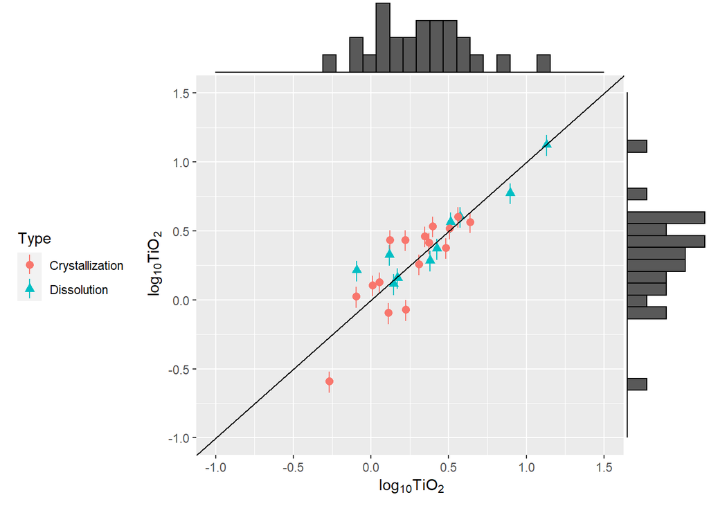

```r
p <- ggplot(RegModel, aes(x = logTiO2, y = logTiO2sat, ymin = log10(lower), ymax = log10(upper), shape = Type, color = Type)) +
  geom_pointrange() +
 # geom_text(label = RegModel$Expt, nudge_x = 0.25, nudge_y = 0.25) +
  geom_abline(slope = 1, intercept = 0) +
  xlim(-1,1.5) +
  ylim(-1,1.5) +
  theme(legend.position = "left") +
  ylab(~paste("log"[10], "TiO"[2][,sat])) +
  xlab(~paste("log"[10], "TiO"[2][,meas]))
p1 <- ggMarginal(p, type = "histogram")
print(p1)
```

### TiO2 vs. M plot

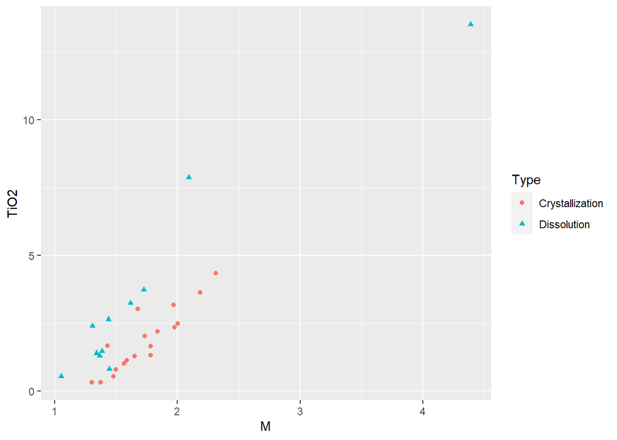

```r
ggplot(RegModel, aes(x = M, y = TiO2, shape = Type, color = Type)) +
  geom_point()
```

### TiO2-TK plot

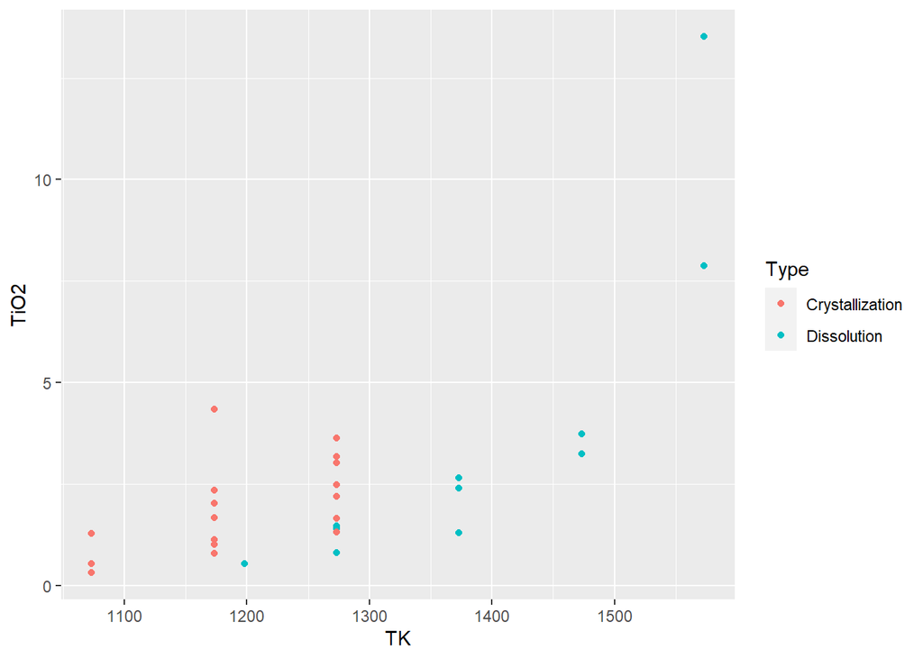

```r
ggplot(RegModel, aes(x = TK, y = TiO2, color = Type)) +
  geom_point()
```

### TiO2-TK plot

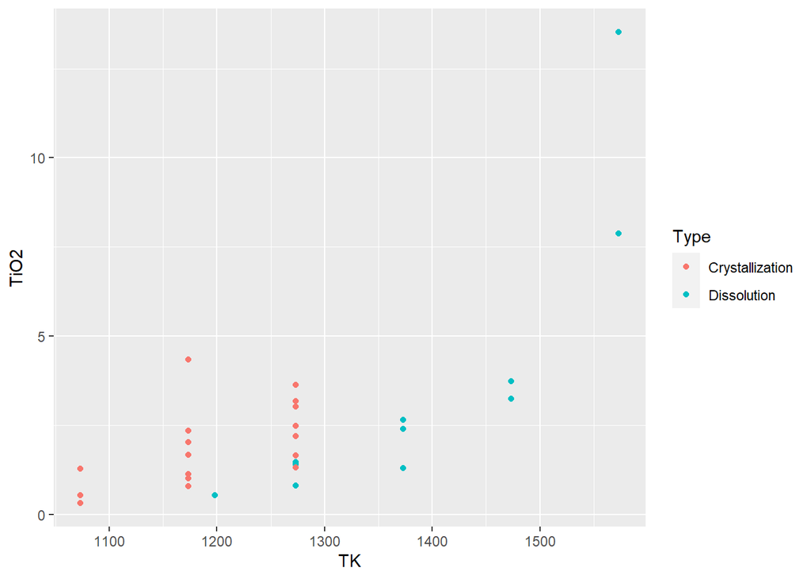

```r
ggplot(RegModel, aes(x = TK, y = TiO2, color = Type)) +
  geom_point()
```

### Model output table

```r
TiO2ModelTable <- select(RegModel, Expt, M, TK, TiO2, TiO2sat,TiO2satSD)
kable(TiO2ModelTable, digits = 2, format = "html",
             col.names = c("Expt.", "M", "T(K)", "TiO~2~", "TiO~2,sat~", "1$\\sigma$"))
```

| Expt. | M | T(K) | TiO<sub>2</sub> | TiO<sub>2,sat</sub> | 1$\sigma$ |
| --- | --- | --- | --- | --- | --- |
| SpDis_10 | 1.31 | 1373.15 | 2.40 | 1.94 | 0.33 |
| SpDis_11 | 1.44 | 1373.15 | 2.65 | 2.36 | 0.41 |
| SpDis_12 | 1.72 | 1473.15 | 3.74 | 4.02 | 0.69 |
| SpDis_13 | 1.62 | 1473.15 | 3.25 | 3.68 | 0.63 |
| SpDis_16 | 1.34 | 1273.15 | 1.40 | 1.31 | 0.22 |
| SpDis_17 | 1.45 | 1273.15 | 0.81 | 1.64 | 0.28 |
| SpDis_18 | 1.05 | 1198.15 | 0.55 | -0.18 | -0.03 |
| SpDis_2 | 2.09 | 1573.15 | 7.88 | 5.95 | 1.02 |
| SpDis_21 | 1.39 | 1273.15 | 1.48 | 1.45 | 0.25 |
| SpDis_3 | 4.39 | 1573.15 | 13.52 | 13.32 | 2.29 |
| SpDis_7 | 1.37 | 1373.15 | 1.31 | 2.13 | 0.37 |
| SpG_10 | 1.68 | 1273.15 | 3.03 | 2.38 | 0.41 |
| SpG_11 | 1.48 | 1073.15 | 0.54 | 0.26 | 0.04 |
| SpG_12 | 1.65 | 1073.15 | 1.29 | 0.81 | 0.14 |
| SpG_15 | 1.31 | 1073.15 | 0.32 | -0.30 | -0.05 |
| SpG_16 | 1.37 | 1073.15 | 0.33 | -0.08 | -0.01 |
| SpG_17 | 1.73 | 1173.15 | 2.04 | 1.82 | 0.31 |
| SpG_18 | 1.98 | 1173.15 | 2.36 | 2.59 | 0.45 |
| SpG_19 | 1.97 | 1273.15 | 3.19 | 3.31 | 0.57 |
| SpG_20 | 2.18 | 1273.15 | 3.64 | 4.01 | 0.69 |
| SpG_23 | 1.43 | 1173.15 | 1.67 | 0.85 | 0.15 |
| SpG_28 | 2.31 | 1173.15 | 4.35 | 3.68 | 0.63 |
| SpG_29 | 1.78 | 1273.15 | 1.66 | 2.72 | 0.47 |
| SpG_30 | 1.78 | 1273.15 | 1.32 | 2.72 | 0.47 |
| SpG_32 | 1.57 | 1173.15 | 1.02 | 1.28 | 0.22 |
| SpG_33 | 1.84 | 1273.15 | 2.21 | 2.90 | 0.50 |
| SpG_34 | 2.00 | 1273.15 | 2.49 | 3.43 | 0.59 |
| SpG_7 | 1.50 | 1173.15 | 0.80 | 1.06 | 0.18 |
| SpG_8 | 1.59 | 1173.15 | 1.13 | 1.35 | 0.23 |

```r
write.csv(TiO2ModelTable, file = "TiO2ModelTable.csv")
```

### Undersaturation test

Use Model equation to test whether Expts in “NoTitanite” are undersaturated

```r
NoTitaniteModel <- filter(NoTitanite, Rutile == "N")
NoTitaniteModel <- select(NoTitaniteModel, Expt, Type, TiO2, TK, M)
NoTitaniteModel$TiO2sat <- predict(fit, NoTitaniteModel)
CompareTiO2 <- select(NoTitaniteModel, Expt, TiO2, TiO2sat)
CompareTiO2 <- CompareTiO2 %>%
  mutate(
    Model_Correct = if_else(TiO2sat > TiO2, "true", "false")
  )
CompareTiO2
```

| Expt | TiO2 | TiO2sat | Model_Correct |
| --- | --- | --- | --- |
| SpG13 | 3.629 | 4.8274873 | true |
| SpG14 | 4.115 | 3.6510398 | false |
| SpG21 | 4.281 | 4.3973046 | true |
| SpG22 | 4.601 | 5.1670954 | true |
| SpG24 | 1.730 | 1.3524636 | false |
| SpG31 | 1.926 | 0.3626115 | false |

```r
CompareTiO2 %>%
  count(Model_Correct)
```

| Model_Correct | n |
| --- | --- |
| false | 3 |
| true | 3 |

### See how model equation fits LEPR data

### Convert oxides to cation concentrations

```r
LEPR_Expts <- read_csv("LEPR_Titanite_ExptsV2.csv")
LEPR_Cations <- LEPR_Expts %>%
  mutate(
    Si = SiO2 / 60.0848,
    Al = 2 * Al2O3 / 101.961,
    Na = 2 * Na2O / 61.979,
    K = 2 * K2O / 94.194,
    Ca = CaO / 56.0794,
    Fe = FeO / 71.8464,
    Mg = MgO / 40.3044,
    Ti = TiO2 / 79.8988,
    CationSum = (Si + Al + Na + K + Ca + Fe + Mg + Ti)
  )
```

### Calculate cation fractions

```r
LEPRCationFractions <- select(LEPR_Cations, Expt, TC, TiO2, Si:CationSum)
f <- match("Si", names(LEPRCationFractions))
l <- match("Ti", names(LEPRCationFractions))
for (i in f:l) {
  LEPRCationFractions[(i)] <- LEPRCationFractions[(i)] / LEPRCationFractions$CationSum
}
```

```r
LEPRCationFractions <- LEPRCationFractions %>%
  mutate(
    M = (Na + K + 2 * Ca) / (Si * Al),
    TK = TC + 273.15,
          )
```

```r
RegModel <- select(LEPRCationFractions, Expt, TiO2, TK, M)
RegModel <- RegModel %>%
  mutate(
    TiO2sat = (out$coefficients[2,1] * M + out$coefficients[3,1] * TK + out$coefficients[1,1]),
    TiO2satSD = TiO2sat * sqrt((out$coefficients[2,2]/ out$coefficients[2,1])^2 + (out$coefficients[3,2] / out$coefficients[3,1])^2),
    lower = TiO2sat - TiO2satSD,
    upper = TiO2sat + TiO2satSD
  )
```

### Plot model versus measured TiO2

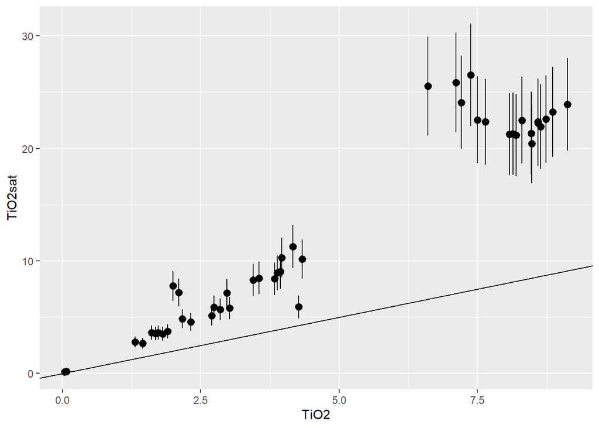

```r
fitparams <- c(out$coefficients[1,1], out$coefficients[2,1],  out$coefficients[3,1])
fitparams <- round(fitparams, digits = 2)
p <- ggplot(RegModel, aes(x = TiO2, y = TiO2sat, ymin = lower, ymax = upper)) +
  geom_pointrange() +
  geom_abline(slope = 1, intercept = 0)
# add marginal distributions
# p1 <- ggMarginal(p, type = "histogram")
print(p)
```

### Statistics

```r
fit <- lm(TiO2sat ~ TiO2, data = RegModel)
summary(fit)
```

```
##
## Call:
## lm(formula = TiO2sat ~ TiO2, data = RegModel)
##
## Residuals:
##     Min      1Q  Median      3Q     Max
## -5.2565 -1.3141 -0.5612  0.2006  7.6227
##
## Coefficients:
##             Estimate Std. Error t value Pr(>|t|)
## (Intercept)  -1.2062     0.7081  -1.703   0.0957 .
## TiO2          2.8958     0.1267  22.852   <2e-16 ***
## ---
## Signif. codes:  0 '***' 0.001 '**' 0.01 '*' 0.05 '.' 0.1 ' ' 1
##
## Residual standard error: 2.448 on 43 degrees of freedom
## Multiple R-squared:  0.9239, Adjusted R-squared:  0.9222
## F-statistic: 522.2 on 1 and 43 DF,  p-value: < 2.2e-16
```

### Model output table

```r
TiO2ModelTable <- select(RegModel, Expt, M, TK, TiO2, TiO2sat,TiO2satSD)
kable(TiO2ModelTable, digits = 2, format = "html",
             col.names = c("Expt.", "M", "T(K)", "TiO~2~", "TiO~2,sat~", "1$\\sigma$"))
```

| Expt. | M | T(K) | TiO<sub>2</sub> | TiO<sub>2,sat</sub> | 1$\sigma$ |
| --- | --- | --- | --- | --- | --- |
| 1044A | 2.36 | 1273.15 | 2.32 | 4.56 | 0.78 |
| 1044BA | 2.71 | 1273.15 | 2.85 | 5.69 | 0.98 |
| 1044T | 2.06 | 1273.15 | 1.73 | 3.62 | 0.62 |
| 1045A | 2.10 | 1273.15 | 1.90 | 3.73 | 0.64 |
| 1045BA | 2.54 | 1273.15 | 2.70 | 5.14 | 0.88 |
| 1045T | 2.06 | 1273.15 | 1.61 | 3.62 | 0.62 |
| 1046A | 1.88 | 1223.15 | 1.45 | 2.67 | 0.46 |
| 1046BA | 2.15 | 1223.15 | 1.68 | 3.54 | 0.61 |
| 1046T | 1.92 | 1223.15 | 1.31 | 2.79 | 0.48 |
| 1056A | 2.44 | 1273.15 | 2.17 | 4.83 | 0.83 |
| 1056BA | 2.77 | 1273.15 | 2.74 | 5.89 | 1.01 |
| 1056T | 2.03 | 1273.15 | 1.81 | 3.51 | 0.60 |
| ASI220 | 7.18 | 1423.15 | 8.20 | 21.19 | 3.64 |
| ASI240 | 3.75 | 1423.15 | 4.33 | 10.17 | 1.75 |
| ASI250 | 2.81 | 1423.15 | 2.97 | 7.15 | 1.23 |
| ASI260 | 2.39 | 1423.15 | 3.02 | 5.79 | 0.99 |
| ASI280 | 2.43 | 1423.15 | 4.27 | 5.90 | 1.01 |
| DAC | 3.01 | 1423.15 | 2.00 | 7.76 | 1.33 |
| HL220-100 | 7.62 | 1423.15 | 8.74 | 22.60 | 3.88 |
| HL220-1500 | 7.51 | 1423.15 | 8.59 | 22.23 | 3.82 |
| HL220-15000 | 7.59 | 1423.15 | 8.30 | 22.48 | 3.86 |
| HL220-25 | 7.42 | 1423.15 | 8.64 | 21.94 | 3.77 |
| HL220-250 | 8.03 | 1423.15 | 9.12 | 23.91 | 4.11 |
| HL220-2500 | 7.55 | 1423.15 | 8.59 | 22.35 | 3.84 |
| HL220-40000 | 7.54 | 1423.15 | 7.64 | 22.35 | 3.84 |
| HL220-50 | 7.82 | 1423.15 | 8.86 | 23.25 | 3.99 |
| HL220-5000 | 7.21 | 1423.15 | 8.08 | 21.26 | 3.65 |
| HL220-60000 | 8.64 | 1423.15 | 7.11 | 25.86 | 4.44 |
| HL220-75000 | 8.08 | 1423.15 | 7.21 | 24.09 | 4.14 |
| HL220-without | 7.23 | 1423.15 | 8.47 | 21.35 | 3.67 |
| HL22REE-200 | 6.94 | 1423.15 | 8.48 | 20.41 | 3.51 |
| HL22REE-2000 | 7.21 | 1423.15 | 8.14 | 21.29 | 3.66 |
| HL22REE-8000 | 7.60 | 1423.15 | 7.50 | 22.54 | 3.87 |
| HL240-100 | 3.37 | 1423.15 | 3.88 | 8.94 | 1.54 |
| HL240-2000 | 3.22 | 1423.15 | 3.55 | 8.47 | 1.46 |
| HL240-20000 | 3.79 | 1423.15 | 3.96 | 10.29 | 1.77 |
| HL240-250 | 3.41 | 1423.15 | 3.94 | 9.05 | 1.56 |
| HL240-45000 | 4.10 | 1423.15 | 4.16 | 11.29 | 1.94 |
| HL240-500 | 3.17 | 1423.15 | 3.45 | 8.30 | 1.43 |
| HL240-5000 | 3.21 | 1423.15 | 3.83 | 8.41 | 1.45 |
| ND-002-18 | 1.56 | 1025.15 | 0.07 | 0.17 | 0.03 |
| ND-002-20 | 1.56 | 1025.15 | 0.04 | 0.14 | 0.02 |
| RHY | 2.82 | 1423.15 | 2.10 | 7.17 | 1.23 |
| SH2K | 8.53 | 1423.15 | 6.60 | 25.53 | 4.39 |
| SH2Na | 8.84 | 1423.15 | 7.38 | 26.52 | 4.56 |

```r
save.image("TitaniteExptsM.RData")
```

# References

Ryerson, F J, and E B Watson. 1987. “Rutile saturation in magmas: implications for Ti-Nb-Ta depletion in island-arc basalts.” *Earth and Planetary Science Letters* 86: 225–39.